# Machine Learning Assignment 1

SrushtiP

10/27/2019

Problem Statement:

This assignment will concentrate on using R and Git. Specifically, you will do the following:

- Download a dataset from the web. You may use any source, but specify the source in your code. Also ensure that the data has a mix of quantitative and qualitative (categorical) variables.
- Import the dataset into R
- Print out descriptive statistics for a selection of quantitative and categorical variables.
- Transform at least one variable. It doesn’t matter what the transformation is.
- Plot at least one quantitative variable, and one scatterplot
- Source of DataSet:
- https://dasl.datadescription.com/datafiles/?_sfm_cases=4+59943&sort_order=modified+desc&sf_paged=9

To import the dataset in R.

```r
Stream_Statistics <- read.csv("Streams.csv")
```

To inspect your data: head() Prints the 1st 5 entries of each column and tail() Prints the last 5 entries of each column.

```r
head(Stream_Statistics, 5)
```

```
##    Stream Substrate   pH Temp     Bci Hard Alkali Phosphate
## 1    BEAR     Shale 7.00    2 1389.24 51.3    0.0      0.05
## 2    FISH     Shale 7.00    2    1336 68.4   17.1      0.07
## 3     FOX     Shale 6.75    9 1417.27 68.4   51.3      0.04
## 4 GRUNLEY     Shale 7.20    9 1264.47 51.3   51.3      0.11
## 5  ABIJAH     Shale 6.75    8 1412.81 34.2   34.2      0.12
```

```r
tail(Stream_Statistics, 5)
```

```
##               Stream Substrate  pH Temp     Bci  Hard Alkali Phosphate
## 168 LITTLE DEER LICK Limestone 7.6    3 1021.08 136.8  136.8      0.02
## 169     LITTLE SANDY     Shale 6.8    2 1294.55  51.3   34.2      0.01
## 170      TROUT BROOK     Shale 7.2    2 1380.32  68.4   68.4      0.01
## 171        FOX CREEK     Shale 6.8    2 1298.57  68.4   51.3      0.01
## 172     COTTEL CREEK     Shale 6.5    1 1370.31  68.4   51.3      0.01
```

- Descriptive Statistics of the dataset

Summmary() helps describe the data statistics of each column.

If the column is a numeric variable, mean, median, min, max and quartiles are returned. If the column is a factor variable, the number of observations in each group is returned.

```r
summary(Stream_Statistics)
```

```
##      Stream        Substrate        pH             Temp
##  SKINNER:  9   Limestone:77   Min.   :6.400   Min.   : 0.000
##  MILL   :  6   Mixed    :26   1st Qu.:7.000   1st Qu.: 2.000
##  STONY  :  6   Shale    :69   Median :7.275   Median : 3.000
##  BEAR   :  5                  Mean   :7.321   Mean   : 3.881
##  COLD   :  5                  3rd Qu.:7.700   3rd Qu.: 6.000
##  KELSEY :  4                  Max.   :8.200   Max.   :11.000
##  (Other):137
##       Bci           Hard           Alkali         Phosphate
##  *      :  9   Min.   : 34.2   Min.   :  0.00   Min.   :0.0000
##  1326   :  2   1st Qu.: 68.4   1st Qu.: 51.30   1st Qu.:0.0500
##  1000.64:  1   Median :102.6   Median : 68.40   Median :0.0900
##  1010.92:  1   Mean   :142.1   Mean   : 98.96   Mean   :0.1855
##  1021.08:  1   3rd Qu.:205.2   3rd Qu.:171.00   3rd Qu.:0.2000
##  1026.57:  1   Max.   :513.0   Max.   :239.40   Max.   :3.8000
##  (Other):157
```

1. Mean : The Arithmetic Mean is the average of the numbers or a calculated “central” value of a set of numbers.

```r
mean(Stream_Statistics$pH)
```

```
## [1] 7.32093
```

2. Median : The middle value. It’s a robust alternative to mean.

```r
median(Stream_Statistics$Temp)
```

```
## [1] 3
```

3. Mode : The most frequent value

```r
require(modeest)
mfv(Stream_Statistics$pH)
```

```
## [1] 7
```

4. Variance : The variance represents the average squared deviation from the mean.

```r
var(Stream_Statistics$Hard)
```

```
## [1] 11697.51
```

5. Standard Deviation : The standard deviation is the square root of the variance. It measures the average deviation of the values, in the data, from the mean value.

```r
sd(Stream_Statistics$Alkali)
```

```
## [1] 61.85136
```

6. Absolute Deviation : The median absolute deviation (MAD) measures the deviation of the values, in the data, from the median value.

```r
mad(Stream_Statistics$Phosphate)
```

```
## [1] 0.088956
```

7. Minimum Value : Provides the minimum value of the specified column

```r
min(Stream_Statistics$Hard)
```

```
## [1] 34.2
```

8. Maximum Value : Provides the maximum value of the specified column

```r
max(Stream_Statistics$Alkali)
```

```
## [1] 239.4
```

9. Which is the row with minimum of the desired column

```r
Stream_Statistics[which.min(Stream_Statistics$Hard),]
```

```
##   Stream Substrate   pH Temp     Bci Hard Alkali Phosphate
## 5 ABIJAH     Shale 6.75    8 1412.81 34.2   34.2      0.12
```

10. Which is the row with maximum of the desired column

```r
Stream_Statistics[which.max(Stream_Statistics$Alkali),]
```

```
##     Stream Substrate  pH Temp  Bci  Hard Alkali Phosphate
## 107   COLD Limestone 7.9    8 1189 119.7  239.4      3.78
```

11. Range: Range corresponds to biggest value minus the smallest value. It gives you the full spread of the data.

```r
range(Stream_Statistics$Temp)
```

```
## [1]  0 11
```

12. Quantile : quartiles divide the data into 4 parts.

The interquartile range (IQR) - corresponding to the difference between the first and third quartiles - is sometimes used as a robust alternative to the standard deviation.

```r
quantile(Stream_Statistics$Phosphate)
```

```
##   0%  25%  50%  75% 100%
## 0.00 0.05 0.09 0.20 3.80
```

```r
IQR(Stream_Statistics$Phosphate)
```

```
## [1] 0.15
```

- Transformation

Transforming data is one step in addressing data that do not fit model assumptions, and is also used to coerce different variables to have similar distributions.

rcompanion- Library require for function plotNormalHistogram

Histogram for pH value

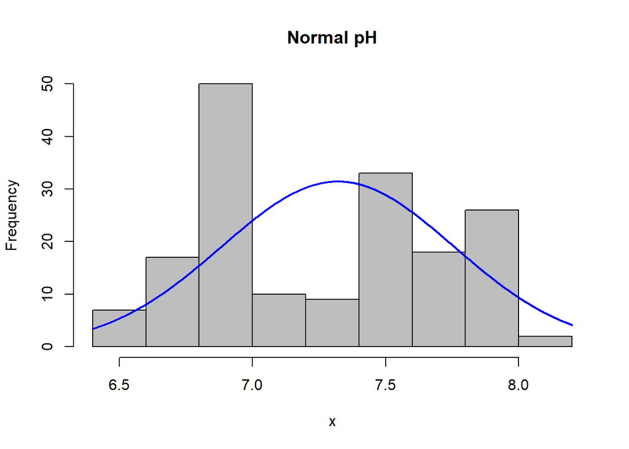

```r
library(rcompanion)

plotNormalHistogram(Stream_Statistics$pH, main = "Normal pH")
```

1. Square Root Transformation

```r
Sq_Trans = sqrt(Stream_Statistics$pH)
print("Square transformation of pH")
```

```
## [1] "Square transformation of pH"
```

```r
print(head(Sq_Trans), 5)
```

```
## [1] 2.6458 2.6458 2.5981 2.6833 2.5981 2.6077
```

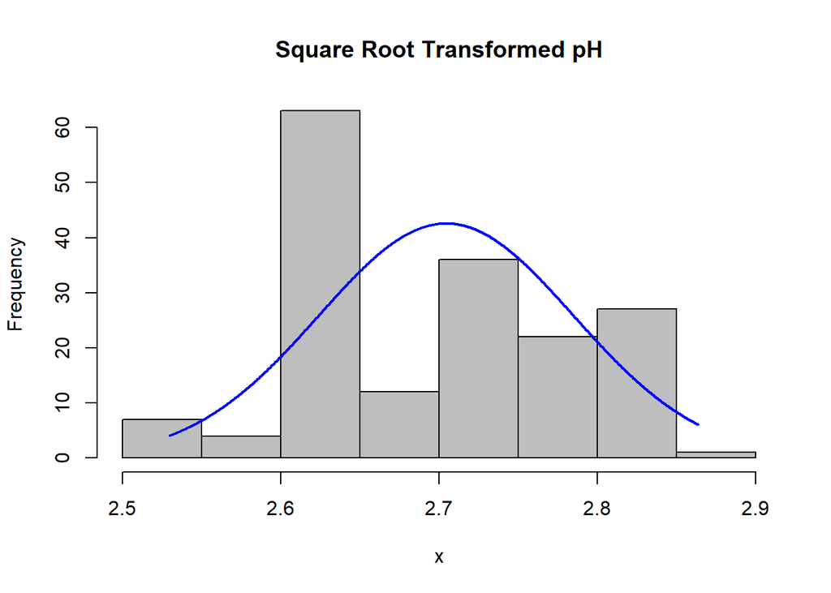

```r
plotNormalHistogram(Sq_Trans, main = "Square Root Transformed pH")
```

2. Cube Root Transformation

```r
C_Trans = abs(Stream_Statistics$pH)^(1/3)
print("Cube Transformation of pH")
```

```
## [1] "Cube Transformation of pH"
```

```r
print (head(C_Trans),5)
```

```
## [1] 1.9129 1.9129 1.8899 1.9310 1.8899 1.8945
```

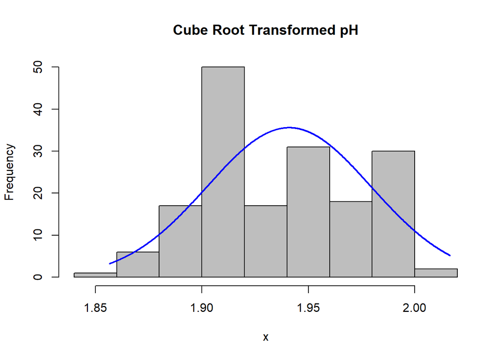

```r
plotNormalHistogram(C_Trans, main = "Cube Root Transformed pH")
```

3. Log Transformation

```r
log_Trans = log(Stream_Statistics$pH)
print("Log Transformation of pH")
```

```
## [1] "Log Transformation of pH"
```

```r
print(head(log_Trans), 5)
```

```
## [1] 1.9459 1.9459 1.9095 1.9741 1.9095 1.9169
```

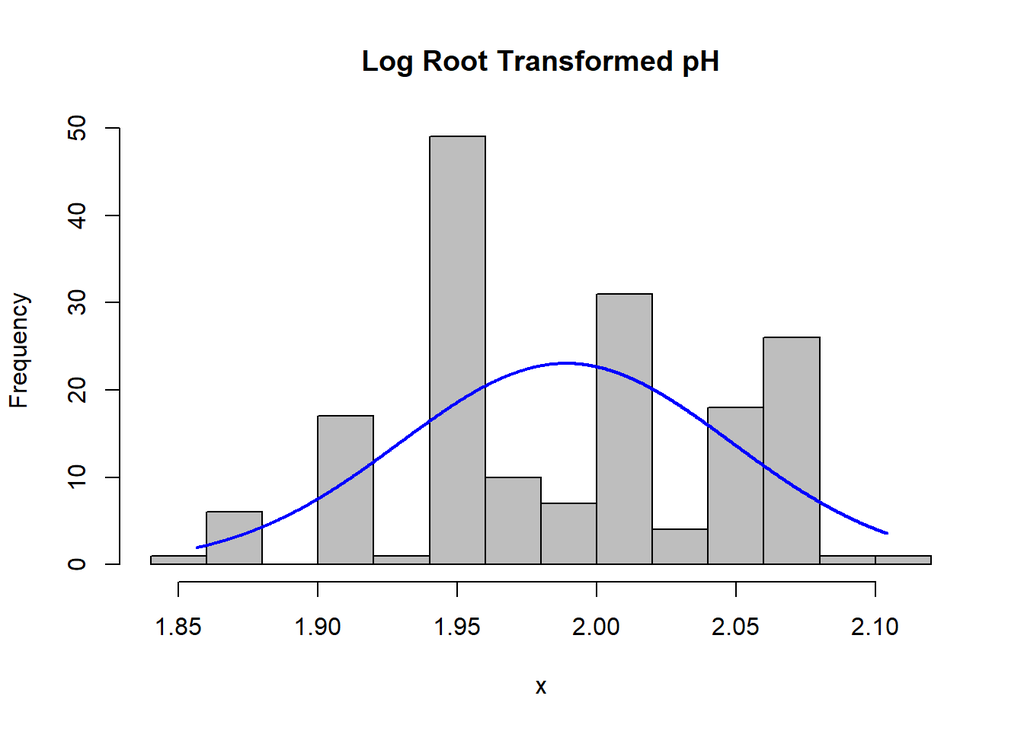

```r
plotNormalHistogram(log_Trans, main = "Log Root Transformed pH")
```

- Graphical Representation
1. Boxplot

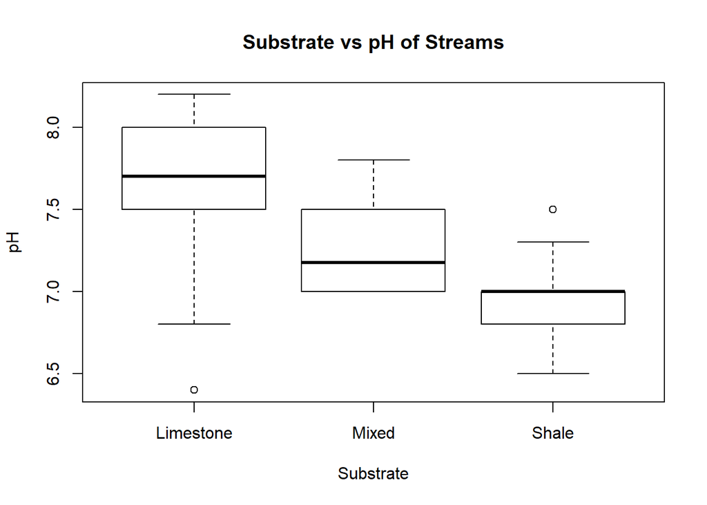

```r
plot(Stream_Statistics$Substrate, Stream_Statistics$pH, xlab = "Substrate", ylab = "pH", main = "Substrate vs pH of Streams")
```

2. Bar Chart - Plotted a graph of number of different substrate

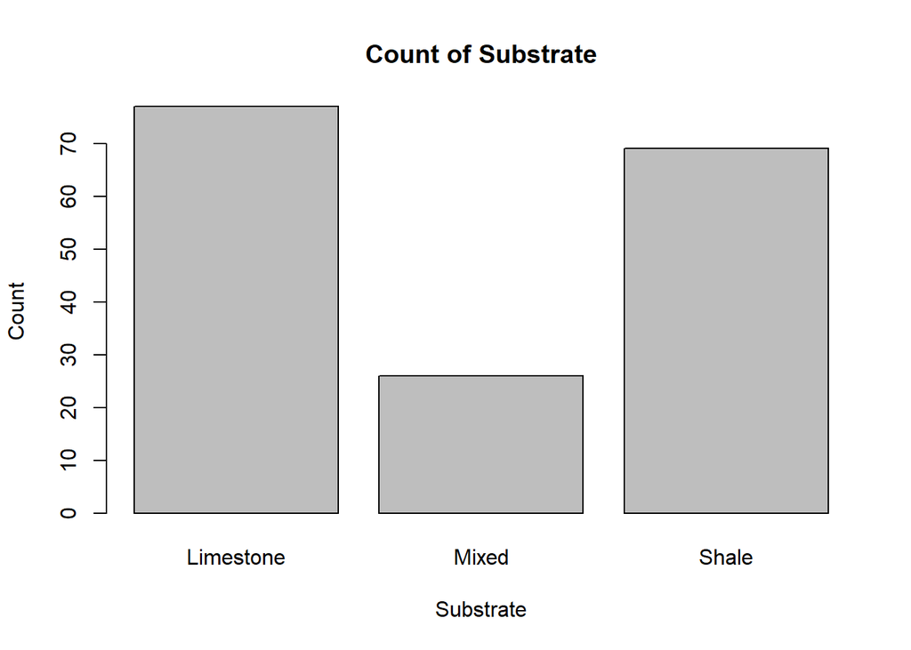

```r
barplot(table(Stream_Statistics$Substrate), xlab = "Substrate", ylab = "Count", main = "Count of Substrate")
```

3. Scatter Plot

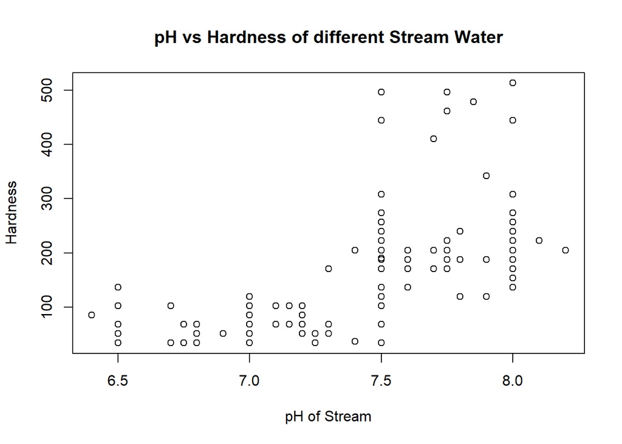

```r
plot.default(Stream_Statistics$pH, Stream_Statistics$Hard, xlab = "pH of Stream", ylab = "Hardness", main = "pH vs Hardness of different Stream Water")
```